# Sara_Ng_Airfoil_Self_noise

### Name: Sara Ng Hui Min

I will be working on the Airfoil Noise Dataset (UCI Machine Learning Repository: Airfoil Self-Noise Data Set), exploring it and building a model to evaluate the performance of the various features on the impact of the noise pressure level.

The data set used comprises of different size NACA 0012 airfoils at various wind tunnel speeds and angles of attack. The span of the airfoil and the observer position were the same in all of the experiments.

#### Attribute Info:

This problem has the following inputs:

1. Frequency, in Hertz.
2. Angle of attack, in degrees.
3. Chord length, in meters.
4. Free-stream velocity, in meters per second.
5. Suction side displacement thickness, in meters.

The only output is:

1. Scaled sound pressure level, in decibels.

```python
import pandas as pd
import numpy as np
import matplotlib.pyplot as plt
import seaborn as sns
```

### 1. Data Visualization and Exploration

- Print 2 rows for sanity check to identify all the features present in the dataset and if the target matches with them.
- Comment on class imbalance with appropriate visualization method.
- Provide appropriate visualizations to get an insight about the dataset.
- Do the correlational analysis on the dataset. Provide a visualization for the same. Will this correlational analysis have effect on feature selection that you will perform in the next step? Justify your answer.

```python
# retrieving dataset
url_file = 'https://archive.ics.uci.edu/ml/machine-learning-databases/00291/airfoil_self_noise.dat'
airfoil_noise_dataset = pd.read_csv(url_file, sep='\t', header=None)

# adding column name to the respective columns
airfoil_noise_dataset.columns =['Frequency', 'Angle', 'Chord_length', 'Velocity', 'Displacement_thicknesss', 'Sound_pressure']

# sanity check on first 2 rows of dataset
airfoil_noise_dataset.head(2)
```

|  | Frequency | Angle | Chord_length | Velocity | Displacement_thicknesss | Sound_pressure |
| --- | --- | --- | --- | --- | --- | --- |
| 0 | 800 | 0.0 | 0.3048 | 71.3 | 0.002663 | 126.201 |
| 1 | 1000 | 0.0 | 0.3048 | 71.3 | 0.002663 | 125.201 |

```python
# sanity check no blank rows at the end of the dataset
airfoil_noise_dataset.tail()
```

|  | Frequency | Angle | Chord_length | Velocity | Displacement_thicknesss | Sound_pressure |
| --- | --- | --- | --- | --- | --- | --- |
| 1498 | 2500 | 15.6 | 0.1016 | 39.6 | 0.052849 | 110.264 |
| 1499 | 3150 | 15.6 | 0.1016 | 39.6 | 0.052849 | 109.254 |
| 1500 | 4000 | 15.6 | 0.1016 | 39.6 | 0.052849 | 106.604 |
| 1501 | 5000 | 15.6 | 0.1016 | 39.6 | 0.052849 | 106.224 |
| 1502 | 6300 | 15.6 | 0.1016 | 39.6 | 0.052849 | 104.204 |

```python
# verifies the number of datapoints and the number of attributes of the dataset
airfoil_noise_dataset.shape
```

```
(1503, 6)
```

```python
# confirms that there is no null values
airfoil_noise_dataset.isnull().sum()
```

```
Frequency                  0
Angle                      0
Chord_length               0
Velocity                   0
Displacement_thicknesss    0
Sound_pressure             0
dtype: int64
```

```python
# provides further details of the dataset like the data type
airfoil_noise_dataset.info()
```

```
<class 'pandas.core.frame.DataFrame'>
RangeIndex: 1503 entries, 0 to 1502
Data columns (total 6 columns):
 #   Column                   Non-Null Count  Dtype
---  ------                   --------------  -----
 0   Frequency                1503 non-null   int64
 1   Angle                    1503 non-null   float64
 2   Chord_length             1503 non-null   float64
 3   Velocity                 1503 non-null   float64
 4   Displacement_thicknesss  1503 non-null   float64
 5   Sound_pressure           1503 non-null   float64
dtypes: float64(5), int64(1)
memory usage: 70.6 KB
```

There is no missing data and no null values and all data are either integer or float values.

```python
# provides statistical data of the dataset
airfoil_noise_dataset.describe()
```

|  | Frequency | Angle | Chord_length | Velocity | Displacement_thicknesss | Sound_pressure |
| --- | --- | --- | --- | --- | --- | --- |
| count | 1503.000000 | 1503.000000 | 1503.000000 | 1503.000000 | 1503.000000 | 1503.000000 |
| mean | 2886.380572 | 6.782302 | 0.136548 | 50.860745 | 0.011140 | 124.835943 |
| std | 3152.573137 | 5.918128 | 0.093541 | 15.572784 | 0.013150 | 6.898657 |
| min | 200.000000 | 0.000000 | 0.025400 | 31.700000 | 0.000401 | 103.380000 |
| 25% | 800.000000 | 2.000000 | 0.050800 | 39.600000 | 0.002535 | 120.191000 |
| 50% | 1600.000000 | 5.400000 | 0.101600 | 39.600000 | 0.004957 | 125.721000 |
| 75% | 4000.000000 | 9.900000 | 0.228600 | 71.300000 | 0.015576 | 129.995500 |
| max | 20000.000000 | 22.200000 | 0.304800 | 71.300000 | 0.058411 | 140.987000 |

As the range of each column is different, normalization is required before training.

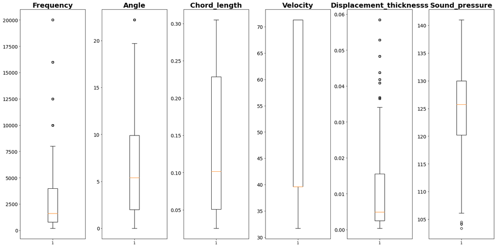

```python
#Creating subplot of each column to check for outliers
fig, axs = plt.subplots(1, len(airfoil_noise_dataset.columns), figsize=(20,10))

for i, ax in enumerate(axs.flat):
    ax.boxplot(airfoil_noise_dataset.iloc[:,i])
    ax.set_title(airfoil_noise_dataset.columns[i], fontsize=20, fontweight='bold')
    ax.tick_params(axis='y', labelsize=14)

plt.tight_layout()
```

Based on the boxplot, observed that there are some outliers to the sound pressure level readings. However, as there are only 1503 data points, outliers will not be removed in the model training.

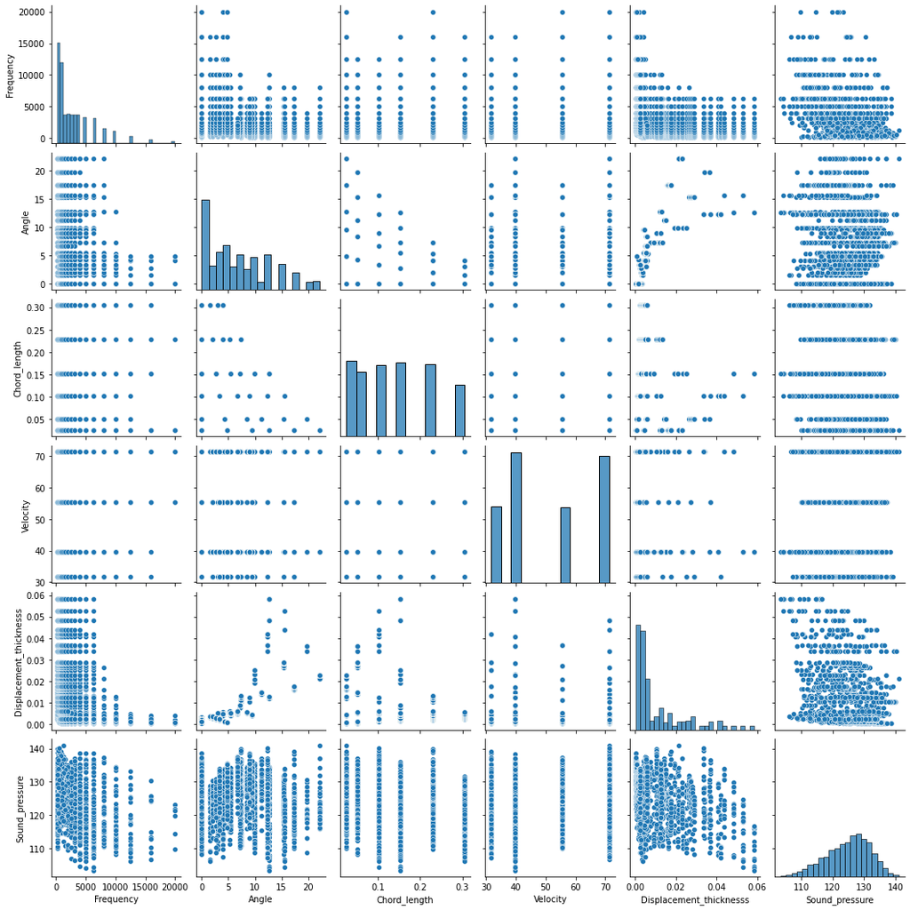

```python
# displays the distribution of the various features
airfoil_noise_plot = airfoil_noise_dataset.copy()
sns.pairplot(airfoil_noise_plot)
```

Observations:

- From the pairplot, there are only 6 chord lengths and 4 free-stream velocities.
- There does not seem to be a linear correlation between sound pressure and the other 5 variables. This likely means that linear regression would not give good results and a non-linear model would give better results for the prediction.

```python
print(airfoil_noise_plot["Chord_length"].value_counts(),'\n')
print(airfoil_noise_plot["Velocity"].value_counts())
```

```
0.0254    278
0.1524    271
0.2286    266
0.1016    263
0.0508    237
0.3048    188
Name: Chord_length, dtype: int64

39.6    480
71.3    465
31.7    281
55.5    277
Name: Velocity, dtype: int64
```

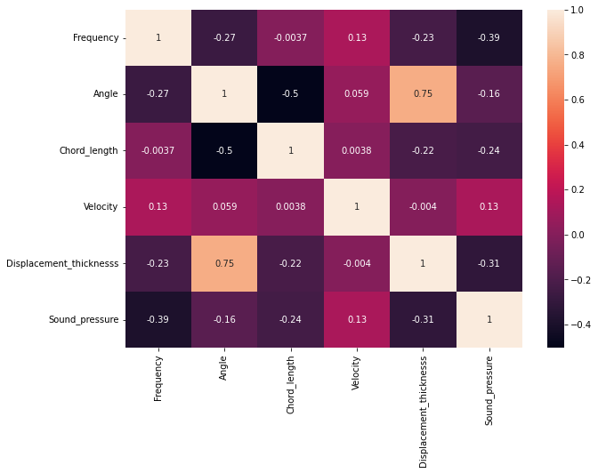

```python
plt.figure(figsize = (10,7))     # Size of the figure
sns.heatmap(airfoil_noise_plot.corr(),annot = True)
```

Based on the correlation matrix, 'Displacement_thickness' column can be dropped from the feature set as 'Displacement_thickness' has a strong correlation with 'Angle'. Thus, the feauture set used for training the model will only compose of 'Frequency', 'Angle', 'Chord_length' and 'Velocity'.

### 2. Data Pre-processing and cleaning

- Do the appropriate pre-processing of the data like identifying NULL or Missing Values if any, handling of outliers if present in the dataset, skewed data etc.
- Mention the pre-processing steps performed in the markdown cell. Explore a few latest data balancing tasks and their effect on model evaluation parameters.
- Apply appropriate feature engineering techniques for them. Apply the feature transformation techniques like Standardization, Normalization, etc. You can apply the appropriate transformations depending on your dataset’s structure and complexity. Provide proper justification. Techniques used without justification will not be awarded marks. Explore a few techniques for identifying feature importance for your feature engineering task.

```python
from sklearn.preprocessing import StandardScaler
```

Based on the analysis covered in section 1, there is no required treatment for NULL or mising values. 'Displacement_thickness' column will not be included in the feature set. Hence, the pre-processing that will be done is to normalize the dataset.

```python
# Putting feature variable to X
X_beforess = airfoil_noise_dataset[['Frequency', 'Angle', 'Chord_length', 'Velocity']]

# Putting response variable to y
y = airfoil_noise_dataset['Sound_pressure']
```

```python
# standardize features by removing the mean and scaling to unit variance.
X = StandardScaler().fit_transform(X_beforess)
```

### 3. Model Building

- Split the dataset into training and test sets. Answer without justification will not be awarded marks.  
  Case 1: Train = 80 % Test = 20% [ x_train1, y_train1] = 80%; [ x_test1, y_test1] = 20%;  
  Case 2: Train = 10 % Test = 90% [ x_train2, y_train2] = 10%; [ x_test2, y_test2] = 90%
- Explore k-fold cross-validation.
- Build Model/s using 1) Linear Regression (SK learn or other libraries can be used)

```python
from sklearn.model_selection import train_test_split
from sklearn.linear_model import LinearRegression
from sklearn.metrics import r2_score, mean_squared_error
from sklearn.model_selection import KFold
```

```python
# Case 1:
X_train1, X_test1, y_train1, y_test1 = train_test_split(X, y, test_size = 0.2, random_state=100)
```

```python
# training linear regression model for case 1
lr = LinearRegression()
lr.fit(X_train1,y_train1)
y_pre1 = lr.predict(X_test1)
acc1 = r2_score(y_test1, y_pre1)
rmse1 = mean_squared_error(y_test1, y_pre1, squared=False)

print(f"R2 score for Case 1: {acc1}")
print(f"RMSE score for Case 1: {rmse1}")
```

```
R2 score for Case 1: 0.49846589167833033
RMSE score for Case 1: 5.02420846144315
```

R² shows how well the data fit the regression model. The higher the R², the better the model fits the data. The Root mean squared error (RMSE) tells how concentrated the data is around the line of best fit. The lower the value, the better the model.

Based on the results from Case 1, the model has an accuracy score of about 0.5 and a RMSE score of about 5. This indicates that linear regression may not be the most suitable model for this dataset.

```python
# Case 2:
X_train2, X_test2, y_train2, y_test2 = train_test_split(X, y, test_size = 0.9, random_state=100)
```

```python
# training linear regression model for case 2
lr = LinearRegression()
lr.fit(X_train2,y_train2)
y_pre2 = lr.predict(X_test2)
acc2 = r2_score(y_test2, y_pre2)
rmse2 = mean_squared_error(y_test2, y_pre2, squared=False)

print(f"R2 score for Case 2: {acc2}")
print(f"RMSE score for Case 2: {rmse2}")
```

```
R2 score for Case 2: 0.4703380212638746
RMSE score for Case 2: 4.995279388919631
```

Based on the results from Case 2, the model has an accuracy score of about 0.47 and a RMSE score of about 5. Similar to Case 1, changing the train/ test data split ratio gave similar results in terms of model performance.

```python
# training linear regression model with k-fold cross-validation
kf = KFold(n_splits=10, random_state=100, shuffle=True)  # 10-fold cross validation

kfold_r2 = []     # storing the r2 for each fold
kfold_rmse = []   # storing the rmse for each fold

lr = LinearRegression()

X_kf = pd.DataFrame(X)
y_kf = y

for train_index, test_index in kf.split(X_kf):
    X_train, X_test = X_kf.iloc[train_index], X_kf.iloc[test_index]
    y_train, y_test = y_kf.iloc[train_index], y_kf.iloc[test_index]

    mod = lr.fit(X_train, y_train)
    y_pred = lr.predict(X_test)

    kf_acc = r2_score(y_test, y_pred)
    kf_RMSE = mean_squared_error(y_test, y_pred, squared=False)
    kfold_r2.append(kf_acc)
    kfold_rmse.append(kf_RMSE)

print("The R2 score for each fold is:\n", kfold_r2, "\n")
print("The RSME for each fold is:\n", kfold_rmse, "\n")
print("*********************************************")
print(f"Overall R2 score: {np.mean(kfold_r2)}")
print(f"Overall RMSE score: {np.mean(kfold_rmse)}")
```

```
The R2 score for each fold is:
 [0.526207764236488, 0.449194836244716, 0.4321234864891459, 0.5126509749613176, 0.3430931720324448, 0.48562919002066773, 0.37982591950645694, 0.49545551360334916, 0.5818662055880105, 0.5004762738019995]

The RSME for each fold is:
 [5.4700196288516185, 4.523748116957172, 5.327367708595751, 4.9510507275543985, 5.325114657292491, 4.856457178662371, 5.175286445102654, 4.5604033094008924, 4.423828424372676, 5.0763466330868]

Overall R2 score: 0.47065233364845965
Overall RMSE score: 4.9689622829876825
```

Based on the results from k-fold cross-validation, the model has an accuracy score of about 0.47 and a RMSE score of around 5. This further reinforces that linear regression may not be the most suitable model to use.

### 4. Performance Evaluation

- Do the prediction for the test data and display the results for the inference. Calculate all the evaluation metrics and choose the best for your model. Justify your answer. Answers without justification will not be awarded marks.
- List out the performance measures in a tabular format. (Accuracy, F1-score, Efficiency, sensitivity or specificity)

```python
from sklearn.tree import DecisionTreeRegressor
from sklearn.linear_model import Ridge
from sklearn.svm import SVR
```

```python
# evaluating the different models
lr = LinearRegression()
r = Ridge()
dt = DecisionTreeRegressor(random_state=100)
svr = SVR(kernel = 'rbf')

print("R2 score and RMSE for selected features:\n")

models = [lr, r, dt, svr]
r2_all = []     # storing the r2 for each fold
rmse_all = []   # storing the rmse for each fold

i = 1
for mod in models:
    mod.fit(X_train1, y_train1)
    y_pred = mod.predict(X_test1)
    acc = r2_score(y_test1, y_pred)
    rmse = mean_squared_error(y_test1, y_pred, squared=False)
    r2_all.append(acc)
    rmse_all.append(rmse)

    print(f"{i}. {mod}:")
    print(f"R2 score for {mod}: {acc}")
    print(f"RMSE score for {mod}: {rmse} \n")
    print("*************************************\n")
    i+=1
```

```
R2 score and RMSE for selected features:

1. LinearRegression():
R2 score for LinearRegression(): 0.49846589167833033
RMSE score for LinearRegression(): 5.02420846144315


2. Ridge():
R2 score for Ridge(): 0.49825089310917614
RMSE score for Ridge(): 5.025285239544528


3. DecisionTreeRegressor(random_state=100):
R2 score for DecisionTreeRegressor(random_state=100): 0.868767374557402
RMSE score for DecisionTreeRegressor(random_state=100): 2.5700307662623194


4. SVR():
R2 score for SVR(): 0.692278913465759
RMSE score for SVR(): 3.9354648905004166
```

```python
# listing out the performance measures in a tabular format

Report = {"Model":["Linear Regression", "Ridge", "Decision Tree", "SVR"]}
Report = pd.DataFrame(Report)
Report['R2_Score'] = pd.Series(r2_all)
Report['RMSE'] = pd.Series(rmse_all)

display(Report)
```

|  | Model | R2_Score | RMSE |
| --- | --- | --- | --- |
| 0 | Linear Regression | 0.498466 | 5.024208 |
| 1 | Ridge | 0.498251 | 5.025285 |
| 2 | Decision Tree | 0.868767 | 2.570031 |
| 3 | SVR | 0.692279 | 3.935465 |

### Conclusion:

The decision tree model has the highest R² score of 0.87 and the lowest RMSE value of 2.6. As such, it is the better model for this dataset. Decision tree regression is also a more suitable model for non-linear regression.